# Regression Final Group Project_Group A

Meng-Hsuan Ho, Pin Tzu Tseng, & Dongni Li

2024-12-10

## 1. Identify a data Table/Data Source that satisfies the requirements for your Project

**Ans**

- one dependent variable: Exam_Score
- 5 or more independent variables: Hours_Studied, Attendance, Extracurricular_Activities, Sleep_Hours, Motivation_Level, Tutoring_Sessions, School_Type
- two or more of the independent variables being categorical: Extracurricular_Activities, Motivation_Level, School_Type
- at least 100 observational rows: the data set has 6,607 observational rows

## 2. Describe your Data

**Ans** This dataset provides a comprehensive overview of various factors affecting student performance in exams. It includes information on study habits, attendance, parental involvement, and other aspects influencing academic success.

## 3. Use R code to import your Data Table into R Studio.

```r
stu_perform <- read_csv("StudentPerformanceFactors.csv")
stu_perform
```

```
## # A tibble: 6,607 × 20
##    Hours_Studied Attendance Parental_Involvement Access_to_Resources
##            <dbl>      <dbl> <chr>                <chr>
##  1            23         84 Low                  High
##  2            19         64 Low                  Medium
##  3            24         98 Medium               Medium
##  4            29         89 Low                  Medium
##  5            19         92 Medium               Medium
##  6            19         88 Medium               Medium
##  7            29         84 Medium               Low
##  8            25         78 Low                  High
##  9            17         94 Medium               High
## 10            23         98 Medium               Medium
## # ℹ 6,597 more rows
## # ℹ 16 more variables: Extracurricular_Activities <chr>, Sleep_Hours <dbl>,
## #   Previous_Scores <dbl>, Motivation_Level <chr>, Internet_Access <chr>,
## #   Tutoring_Sessions <dbl>, Family_Income <chr>, Teacher_Quality <chr>,
## #   School_Type <chr>, Peer_Influence <chr>, Physical_Activity <dbl>,
## #   Learning_Disabilities <chr>, Parental_Education_Level <chr>,
## #   Distance_from_Home <chr>, Gender <chr>, Exam_Score <dbl>
```

## 4. Define/Describe all Variables of your Data Table

**Ans**

- Exam_Score: Final exam score.
- Hours_Studied: Number of hours spent studying per week.
- Attendance: Percentage of classes attended.
- Extracurricular_Activities: Participation in extracurricular activities (Yes, No).
- Sleep_Hours: Average number of hours of sleep per night.
- Motivation_Level: Student’s level of motivation (Low, Medium, High).
- Tutoring_Sessions: Number of tutoring sessions attended per month.
- School_Type: Type of school attended (Public, Private).

## 5. Indicate source of your Data Table

**Ans**

[Student Performance Factors](https://www.kaggle.com/datasets/lainguyn123/student-performance-factors/data): This data set is a synthetic dataset generated for educational and analytical purposes. The data is not sourced from any real-world institutions but is created to simulate realistic scenarios for analyzing student performance factors.

## 6. Missing value analysis

```r
stu_perform <- stu_perform |>
  select(Exam_Score, Hours_Studied, Attendance,Extracurricular_Activities,
        Sleep_Hours, Motivation_Level, Tutoring_Sessions,School_Type)
```

```r
sum(is.na(stu_perform))
```

```
## [1] 0
```

```r
colSums(is.na(stu_perform))
```

```
##                 Exam_Score              Hours_Studied
##                          0                          0
##                 Attendance Extracurricular_Activities
##                          0                          0
##                Sleep_Hours           Motivation_Level
##                          0                          0
##          Tutoring_Sessions                School_Type
##                          0                          0
```

There is no missing value in the data set.

## 7. Generate relevant data visual plots that explore multicollinearity for the quantitative variables and normality for the quantitative variables as well. Also, use R code to confirm the levels of the categorical variables. (Pin Tzu)

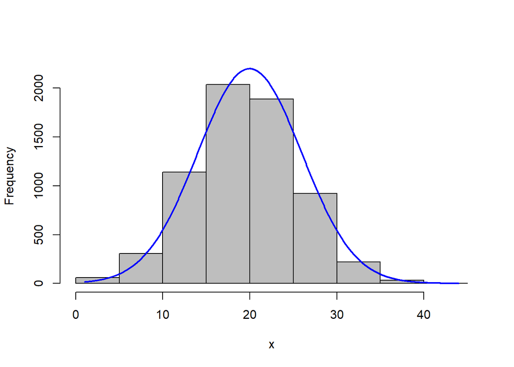

```r
#normality for the quantitative variables

plotNormalHistogram(stu_perform$Hours_Studied)
```

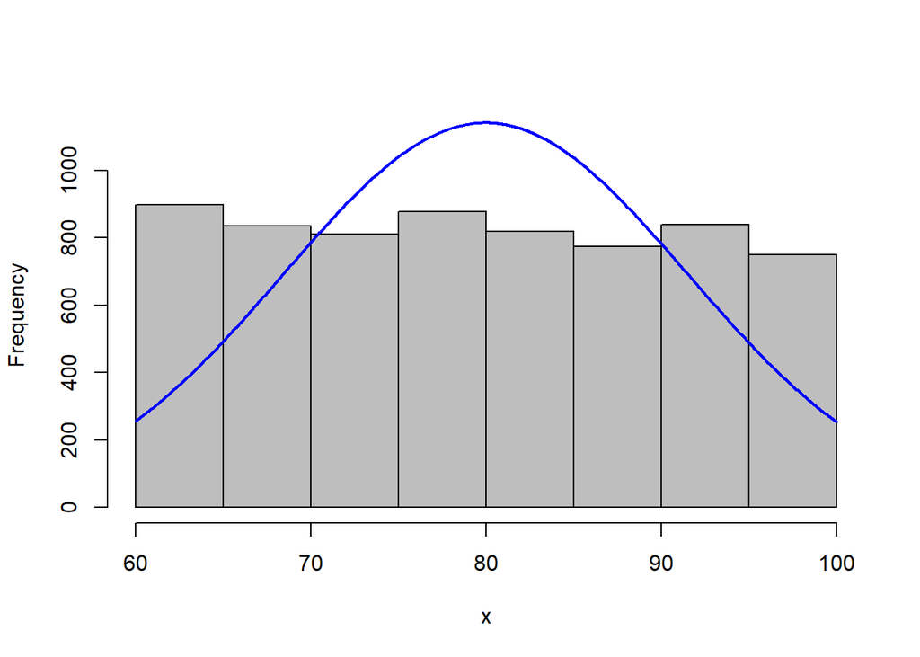

```r
plotNormalHistogram(stu_perform$Attendance)
```

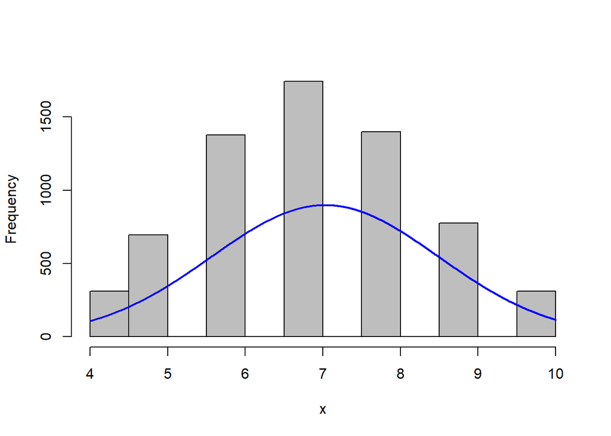

```r
plotNormalHistogram(stu_perform$Sleep_Hours)
```

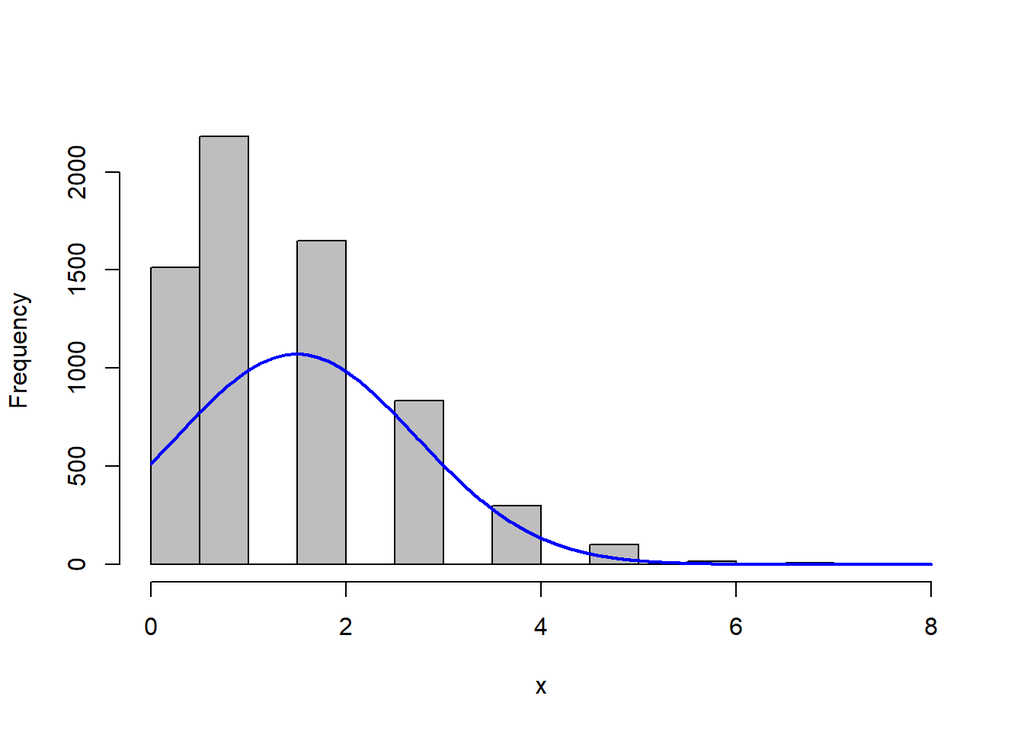

```r
plotNormalHistogram(stu_perform$Tutoring_Sessions)
```

```r
#level of categorical variables
EA <- factor(stu_perform$Extracurricular_Activities)
levels(EA)
```

```
## [1] "No"  "Yes"
```

```r
ML <- factor(stu_perform$Motivation_Level)
levels(ML)
```

```
## [1] "High"   "Low"    "Medium"
```

```r
ST <- factor(stu_perform$School_Type)
levels(ST)
```

```
## [1] "Private" "Public"
```

the level of Extracurricular_Activities is no and yes.

the level of Motivation_Level is high, low, and medium.

the level of School_Type is private and public.

```r
#only quantitative variable multiple regression model
only_numva <-
  stu_perform |>
  select(Exam_Score, Hours_Studied, Attendance,
         Sleep_Hours, Tutoring_Sessions)
only_numva
```

```
## # A tibble: 6,607 × 5
##    Exam_Score Hours_Studied Attendance Sleep_Hours Tutoring_Sessions
##         <dbl>         <dbl>      <dbl>       <dbl>             <dbl>
##  1         67            23         84           7                 0
##  2         61            19         64           8                 2
##  3         74            24         98           7                 2
##  4         71            29         89           8                 1
##  5         70            19         92           6                 3
##  6         71            19         88           8                 3
##  7         67            29         84           7                 1
##  8         66            25         78           6                 1
##  9         69            17         94           6                 0
## 10         72            23         98           8                 0
## # ℹ 6,597 more rows
```

I selected the variables only included quantitative variables to test their multicollinearity.

```r
#multicollinearity for quantitative variables
cor <- cor(only_numva)
cor
```

```
##                    Exam_Score Hours_Studied   Attendance Sleep_Hours
## Exam_Score         1.00000000   0.445454954  0.581071863 -0.01702163
## Hours_Studied      0.44545495   1.000000000 -0.009907859  0.01097669
## Attendance         0.58107186  -0.009907859  1.000000000 -0.01591783
## Sleep_Hours       -0.01702163   0.010976689 -0.015917826  1.00000000
## Tutoring_Sessions  0.15652519  -0.014282264  0.014323509 -0.01221611
##                   Tutoring_Sessions
## Exam_Score               0.15652519
## Hours_Studied           -0.01428226
## Attendance               0.01432351
## Sleep_Hours             -0.01221611
## Tutoring_Sessions        1.00000000
```

They don’t have multicollinearity problem, and I also create a multicollinearity plot.

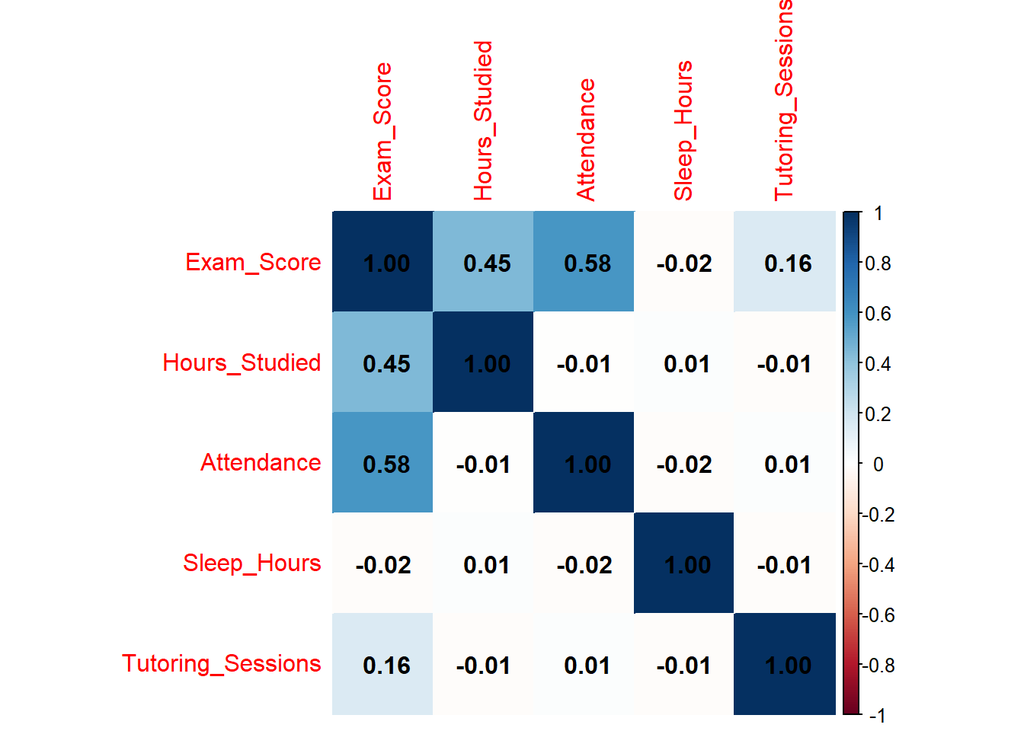

```r
#multicollinearity plot for quantitative variables
corrplot::corrplot(cor, method = "color", addCoef.col = "black")
```

## 8. Using R code, produce a full Regression Model that consists of quantitative and categorical variables. (Pin Tzu)

```r
#full multiple regression model (include all variables)
all_lm <- lm(data = stu_perform, Exam_Score ~ Hours_Studied +
               Attendance+ Extracurricular_Activities + Sleep_Hours +
               Motivation_Level + Tutoring_Sessions + School_Type)
all_lm
```

```
##
## Call:
## lm(formula = Exam_Score ~ Hours_Studied + Attendance + Extracurricular_Activities +
##     Sleep_Hours + Motivation_Level + Tutoring_Sessions + School_Type,
##     data = stu_perform)
##
## Coefficients:
##                   (Intercept)                  Hours_Studied
##                     45.347739                       0.295459
##                    Attendance  Extracurricular_ActivitiesYes
##                      0.196689                       0.526723
##                   Sleep_Hours            Motivation_LevelLow
##                     -0.029212                      -1.045458
##        Motivation_LevelMedium              Tutoring_Sessions
##                     -0.530504                       0.487480
##             School_TypePublic
##                     -0.008441
```

Full model:

Exam_Score = 45.347739 + 0.295459 (Hours_Studied) + 0.196689(Attendance) + 0.526723(Extracurricular_ActivitiesYes)-0.029212(Sleep_Hours) + -1.045458(Motivation_LevelLow)-0.530504(Motivation_LevelMedium) + 0.487480(Tutoring_Sessions)-0.008441(School_TypePublic)

## 9. Make use of the R generated dummy variable matrices(Pin Tzu)

```r
contrasts(as.factor(stu_perform$Extracurricular_Activities))
```

```
##     Yes
## No    0
## Yes   1
```

```r
contrasts(as.factor(stu_perform$Motivation_Level))
```

```
##        Low Medium
## High     0      0
## Low      1      0
## Medium   0      1
```

```r
contrasts(as.factor(stu_perform$School_Type))
```

```
##         Public
## Private      0
## Public       1
```

## 10. Using only the quantitative variables as predictors, produce a model using matrix methods. Also use matrix methods to find the fitted values and the residuals (Dongni)

```r
quantitative_data <- stu_perform[, c("Exam_Score", "Hours_Studied", "Attendance", "Sleep_Hours", "Tutoring_Sessions")]

X <- as.matrix(cbind(1, quantitative_data[, -1]))
y <- as.matrix(quantitative_data$Exam_Score)
```

```r
beta <- solve(t(X) %*% X) %*% t(X) %*% y
beta
```

```
##                          [,1]
## 1                 45.10999572
## Hours_Studied      0.29455346
## Attendance         0.19647899
## Sleep_Hours       -0.02869808
## Tutoring_Sessions  0.48850816
```

quantitative variables model:

Exam_Score = 45.11 + 0.2945535(Hours_Studied) + 0.196479(Attendance) - 0.02869808(Sleep_Hours) + 0.4885082(Tutoring_Sessions)

```r
#fitted value
y_hat <- X %*% beta
head(y_hat)
```

```
##          [,1]
## [1,] 68.18807
## [2,] 64.02860
## [3,] 72.21035
## [4,] 71.39760
## [5,] 70.07591
## [6,] 69.23260
```

```r
# residuals
residuals <- y - y_hat
head(residuals)
```

```
##             [,1]
## [1,] -1.18807345
## [2,] -3.02859815
## [3,]  1.78965097
## [4,] -0.39759920
## [5,] -0.07591407
## [6,]  1.76739803
```

## 11. Produce an output summary table to be used to analyze and evaluate the full model (Adjusted R squared, Standard Error, Significance of Variables, ect…) (Meng Hsuan)

```r
summary(all_lm)
```

```
##
## Call:
## lm(formula = Exam_Score ~ Hours_Studied + Attendance + Extracurricular_Activities +
##     Sleep_Hours + Motivation_Level + Tutoring_Sessions + School_Type,
##     data = stu_perform)
##
## Residuals:
##     Min      1Q  Median      3Q     Max
## -5.8598 -1.2017 -0.1610  0.8929 31.3856
##
## Coefficients:
##                                Estimate Std. Error t value Pr(>|t|)
## (Intercept)                   45.347739   0.300547 150.884  < 2e-16 ***
## Hours_Studied                  0.295459   0.005192  56.901  < 2e-16 ***
## Attendance                     0.196689   0.002694  73.012  < 2e-16 ***
## Extracurricular_ActivitiesYes  0.526723   0.063368   8.312  < 2e-16 ***
## Sleep_Hours                   -0.029212   0.021183  -1.379    0.168
## Motivation_LevelLow           -1.045458   0.090242 -11.585  < 2e-16 ***
## Motivation_LevelMedium        -0.530504   0.082180  -6.455 1.16e-10 ***
## Tutoring_Sessions              0.487480   0.025276  19.286  < 2e-16 ***
## School_TypePublic             -0.008441   0.067605  -0.125    0.901
## ---
## Signif. codes:  0 '***' 0.001 '**' 0.01 '*' 0.05 '.' 0.1 ' ' 1
##
## Residual standard error: 2.527 on 6598 degrees of freedom
## Multiple R-squared:  0.5786, Adjusted R-squared:  0.5781
## F-statistic:  1132 on 8 and 6598 DF,  p-value: < 2.2e-16
```

According to the summary table of full model, it shows that the p value of variable “Sleep_Hours” and “School_TypePublic” is higher than 0.05 which is not significant. Although Tutoring_Sessions is not normality, but its p value show it is significant, so we will consider it in our final model.

Otherwise, the Adjusted R-squared is 0.5781 which indicate approximately half of the observed variation can be explained by the model’s inputs.

Also, residual standard error is 2.527 unit far from the regression line in average.

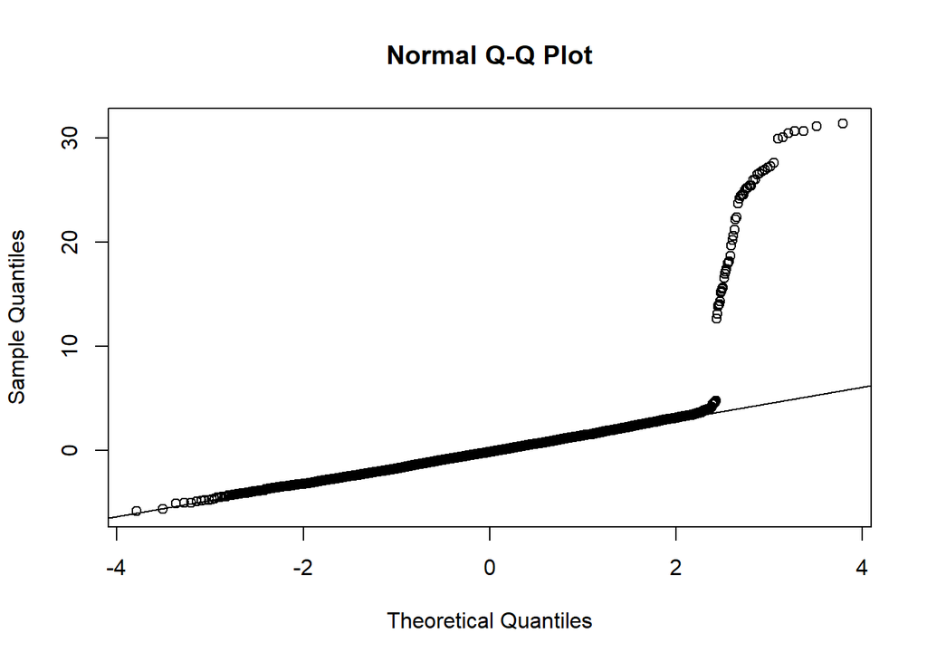

```r
qqnorm(all_lm$residuals)
qqline(all_lm$residuals)
```

We used the residual plot to see the normality. The data points do not always align in the middle of the plot. The distribution of the residuals is not pretty normal. There are lots of outliers.

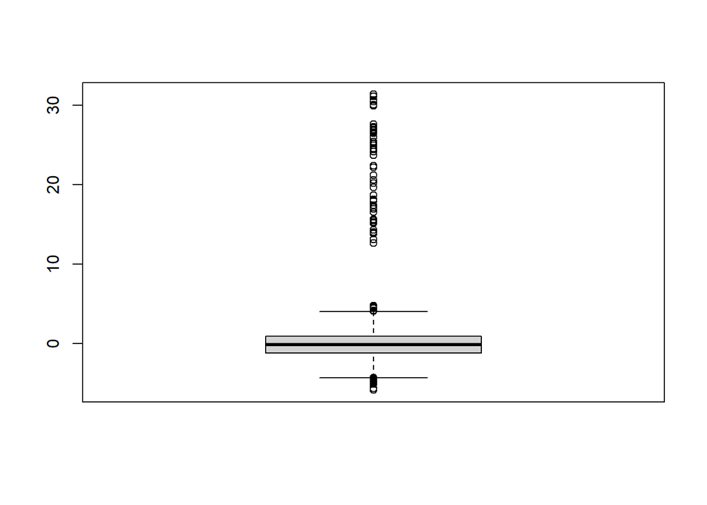

```r
boxplot(all_lm$residuals)
```

The residual boxplot also presents many outliers.

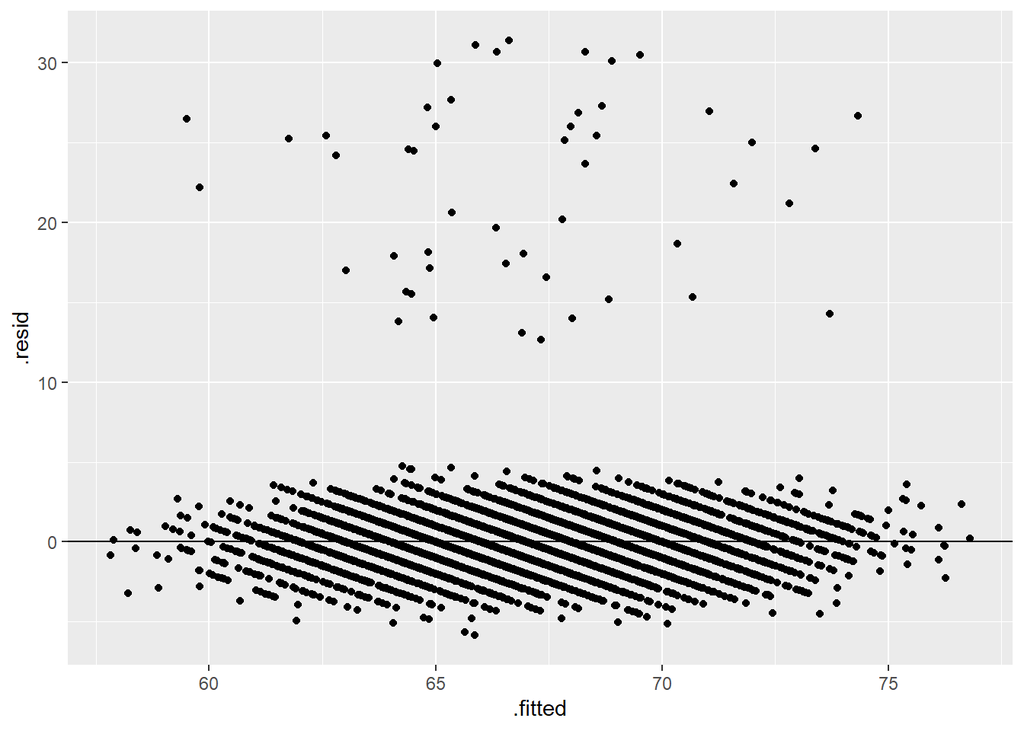

```r
ggplot(all_lm, aes(x = .fitted, y = .resid)) +
  geom_point() +
  geom_hline(yintercept = 0)
```

In this residual plot doesn’t suggest a linear relationship which may caused by many outliers.

We conclude that the data set should be transformed to exclude the outliers.

```r
ex_outlier <- stu_perform |>
  mutate(
    residuals = all_lm$residuals) |>
  filter(residuals <10)
ex_outlier
```

```
## # A tibble: 6,557 × 9
##    Exam_Score Hours_Studied Attendance Extracurricular_Activities Sleep_Hours
##         <dbl>         <dbl>      <dbl> <chr>                            <dbl>
##  1         67            23         84 No                                   7
##  2         61            19         64 No                                   8
##  3         74            24         98 Yes                                  7
##  4         71            29         89 Yes                                  8
##  5         70            19         92 Yes                                  6
##  6         71            19         88 Yes                                  8
##  7         67            29         84 Yes                                  7
##  8         66            25         78 Yes                                  6
##  9         69            17         94 No                                   6
## 10         72            23         98 Yes                                  8
## # ℹ 6,547 more rows
## # ℹ 4 more variables: Motivation_Level <chr>, Tutoring_Sessions <dbl>,
## #   School_Type <chr>, residuals <dbl>
```

```r
ex_outlier_lm <- lm(data = ex_outlier, Exam_Score ~ Hours_Studied +
               Attendance+ Extracurricular_Activities + Sleep_Hours +
               Motivation_Level + Tutoring_Sessions + School_Type)
summary(ex_outlier_lm)
```

```
##
## Call:
## lm(formula = Exam_Score ~ Hours_Studied + Attendance + Extracurricular_Activities +
##     Sleep_Hours + Motivation_Level + Tutoring_Sessions + School_Type,
##     data = ex_outlier)
##
## Residuals:
##     Min      1Q  Median      3Q     Max
## -5.6022 -1.0397 -0.0042  1.0285  4.8638
##
## Coefficients:
##                                Estimate Std. Error t value Pr(>|t|)
## (Intercept)                   44.921899   0.184071 244.046   <2e-16 ***
## Hours_Studied                  0.299047   0.003178  94.089   <2e-16 ***
## Attendance                     0.197508   0.001648 119.872   <2e-16 ***
## Extracurricular_ActivitiesYes  0.471208   0.038756  12.158   <2e-16 ***
## Sleep_Hours                   -0.009896   0.012961  -0.763    0.445
## Motivation_LevelLow           -1.002195   0.055232 -18.145   <2e-16 ***
## Motivation_LevelMedium        -0.491789   0.050312  -9.775   <2e-16 ***
## Tutoring_Sessions              0.489837   0.015459  31.686   <2e-16 ***
## School_TypePublic             -0.036965   0.041340  -0.894    0.371
## ---
## Signif. codes:  0 '***' 0.001 '**' 0.01 '*' 0.05 '.' 0.1 ' ' 1
##
## Residual standard error: 1.54 on 6548 degrees of freedom
## Multiple R-squared:  0.7886, Adjusted R-squared:  0.7883
## F-statistic:  3053 on 8 and 6548 DF,  p-value: < 2.2e-16
```

After excluding the outliers from the full model, the residual standard error gets smaller and Adjusted R-squared is higher to get close to one which means the full model gets better after transformation.

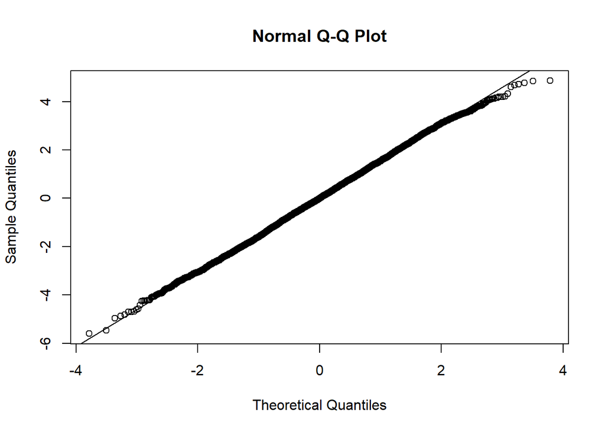

```r
qqnorm(ex_outlier_lm$residuals)
qqline(ex_outlier_lm$residuals)
```

The residual plot shows the data points align on the line after excluding the outliers.

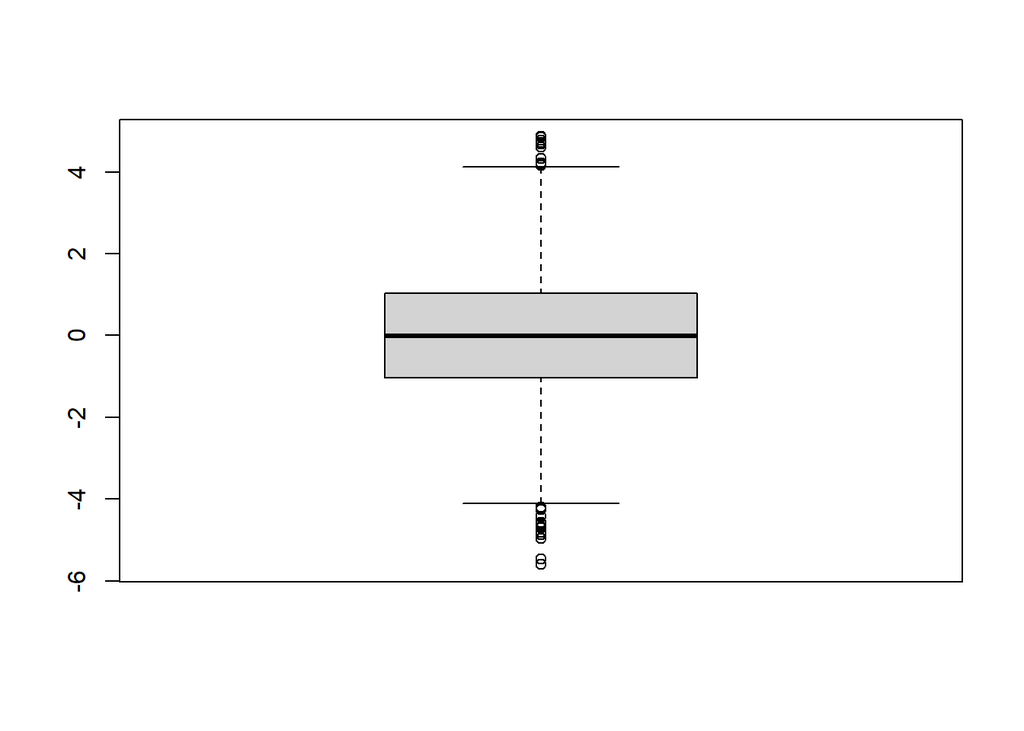

```r
boxplot(ex_outlier_lm$residuals)
```

The outlier is fewer in the boxplot after excluding the outliers.

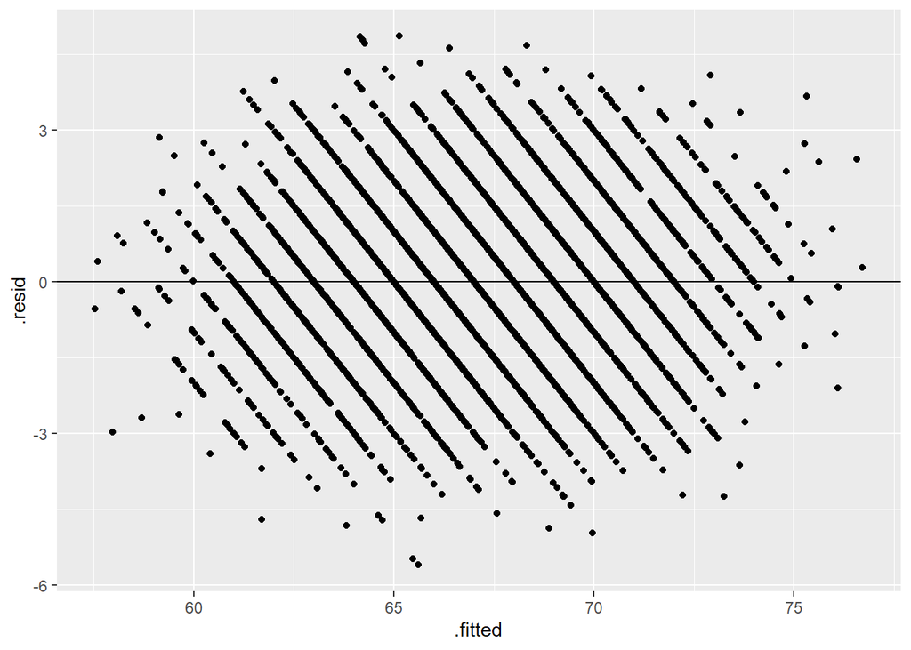

```r
ggplot(ex_outlier_lm, aes(x = .fitted, y = .resid)) +
  geom_point() +
  geom_hline(yintercept = 0)
```

After excluding the outliers, the residual plot suggests a linear relationship because it shows the constant variance.

## 12. Use procedures and techniques explored in class to produce confidence intervals for the independent quantitative variables of your model. Choose at least two of the quantitative variables to find confidence intervals for.(Dongni)

```r
model <- lm(Exam_Score ~ Hours_Studied + Sleep_Hours + Attendance +
              Tutoring_Sessions, data = stu_perform)

confint(model, level = 0.95)
```

```
##                         2.5 %      97.5 %
## (Intercept)       44.53714961 45.68284184
## Hours_Studied      0.28422073  0.30488618
## Sleep_Hours       -0.07086236  0.01346619
## Attendance         0.19111822  0.20183975
## Tutoring_Sessions  0.43820361  0.53881272
```

## 13. Produce a reduced model (removing variables of your choice with justification). Use R summary coding for both models and offer justification for choosing one model over the other. Also apply this model technique: Mallows’s Cp&AIC&SBC with ols_step_best_subset() function from 11/20 model selection.(Meng Hsuan)

Due to the not significant variable “Sleep_Hours” and “School_TypePublic”, we decided to remove them from our model.

Firstly, we examine the model with full data instead of excluding the outliers.

```r
stu_perform_lm2 <- lm(Exam_Score ~ Hours_Studied + Attendance + Extracurricular_Activities + Motivation_Level + Tutoring_Sessions, stu_perform)

summary(stu_perform_lm2)
```

```
##
## Call:
## lm(formula = Exam_Score ~ Hours_Studied + Attendance + Extracurricular_Activities +
##     Motivation_Level + Tutoring_Sessions, data = stu_perform)
##
## Residuals:
##     Min      1Q  Median      3Q     Max
## -5.8246 -1.2040 -0.1659  0.9010 31.3539
##
## Coefficients:
##                                Estimate Std. Error t value Pr(>|t|)
## (Intercept)                   45.132305   0.254494 177.342  < 2e-16 ***
## Hours_Studied                  0.295382   0.005192  56.890  < 2e-16 ***
## Attendance                     0.196754   0.002693  73.058  < 2e-16 ***
## Extracurricular_ActivitiesYes  0.526556   0.063367   8.310  < 2e-16 ***
## Motivation_LevelLow           -1.045182   0.090233 -11.583  < 2e-16 ***
## Motivation_LevelMedium        -0.530397   0.082177  -6.454 1.16e-10 ***
## Tutoring_Sessions              0.487866   0.025273  19.304  < 2e-16 ***
## ---
## Signif. codes:  0 '***' 0.001 '**' 0.01 '*' 0.05 '.' 0.1 ' ' 1
##
## Residual standard error: 2.527 on 6600 degrees of freedom
## Multiple R-squared:  0.5785, Adjusted R-squared:  0.5781
## F-statistic:  1510 on 6 and 6600 DF,  p-value: < 2.2e-16
```

Still, the Adjusted R-squared shows as same.

We used stepwise regression method to choose the best model to predict student exam score.

```r
intercept_only <- lm(Exam_Score ~ 1, data=stu_perform)
intercept_only
```

```
##
## Call:
## lm(formula = Exam_Score ~ 1, data = stu_perform)
##
## Coefficients:
## (Intercept)
##       67.24
```

```r
all <- lm(Exam_Score ~ ., data=stu_perform)
all
```

```
##
## Call:
## lm(formula = Exam_Score ~ ., data = stu_perform)
##
## Coefficients:
##                   (Intercept)                  Hours_Studied
##                     45.347739                       0.295459
##                    Attendance  Extracurricular_ActivitiesYes
##                      0.196689                       0.526723
##                   Sleep_Hours            Motivation_LevelLow
##                     -0.029212                      -1.045458
##        Motivation_LevelMedium              Tutoring_Sessions
##                     -0.530504                       0.487480
##             School_TypePublic
##                     -0.008441
```

```r
forward <- step(intercept_only, direction='forward',
                scope=formula(all), trace=0)
forward
```

```
##
## Call:
## lm(formula = Exam_Score ~ Attendance + Hours_Studied + Tutoring_Sessions +
##     Motivation_Level + Extracurricular_Activities, data = stu_perform)
##
## Coefficients:
##                   (Intercept)                     Attendance
##                       45.1323                         0.1968
##                 Hours_Studied              Tutoring_Sessions
##                        0.2954                         0.4879
##           Motivation_LevelLow         Motivation_LevelMedium
##                       -1.0452                        -0.5304
## Extracurricular_ActivitiesYes
##                        0.5266
```

```r
forward$anova
```

```
##                           Step Df   Deviance Resid. Df Resid. Dev      AIC
## 1                              NA         NA      6606   99986.08 17952.57
## 2                 + Attendance -1 33759.7506      6605   66226.33 15232.79
## 3              + Hours_Studied -1 20358.4031      6604   45867.93 12807.96
## 4          + Tutoring_Sessions -1  2390.2298      6603   43477.70 12456.37
## 5           + Motivation_Level -2   890.8658      6601   42586.83 12323.59
## 6 + Extracurricular_Activities -1   440.9337      6600   42145.90 12256.82
```

We found out the best model is:

Exam_Score = 45.1323 + 0.1968(Attendance) + 0.2954(Hours_Studied) + 0.4879(Tutoring_Sessions) - 1.0452(Motivation_LevelLow) -0.5304(Motivation_LevelMedium) + 0.5266(Extracurricular_ActivitiesYes)

```r
stu_perform_lm3 <- lm(Exam_Score ~ Attendance + Hours_Studied +
    Tutoring_Sessions + Motivation_Level + Extracurricular_Activities,
    data = stu_perform)

ols_step_best_subset(stu_perform_lm3)
```

```
##                                        Best Subsets Regression
## -----------------------------------------------------------------------------------------------------
## Model Index    Predictors
## -----------------------------------------------------------------------------------------------------
##      1         Attendance
##      2         Attendance Hours_Studied
##      3         Attendance Hours_Studied Tutoring_Sessions
##      4         Attendance Hours_Studied Tutoring_Sessions Motivation_Level
##      5         Attendance Hours_Studied Tutoring_Sessions Motivation_Level Extracurricular_Activities
## -----------------------------------------------------------------------------------------------------
##
##                                                          Subsets Regression Summary
## ---------------------------------------------------------------------------------------------------------------------------------------------
##                        Adj.        Pred
## Model    R-Square    R-Square    R-Square      C(p)          AIC           SBIC          SBC           MSEP         FPE       HSP       APC
## ---------------------------------------------------------------------------------------------------------------------------------------------
##   1        0.3376      0.3375      0.3372    3767.9687    33984.6478    15233.0789    34005.0355    66246.3815    10.0297    0.0015    0.6628
##   2        0.5413      0.5411      0.5408     581.8656    31559.8173    12809.4697    31587.0009    45888.7625     6.9486    0.0011    0.4592
##   3        0.5652      0.5650      0.5646     209.5583    31208.2238    12458.1314    31242.2032    43504.0354     6.5885    0.0010    0.4354
##   4        0.5741      0.5737      0.5733      74.0497    31075.4390    12323.4920    31123.0102    42619.0854     6.4565    0.0010    0.4266
##   5        0.5785      0.5781      0.5776       7.0000    31008.6751    12256.8340    31063.0422    42184.2083     6.3915    0.0010    0.4223
## ---------------------------------------------------------------------------------------------------------------------------------------------
## AIC: Akaike Information Criteria
##  SBIC: Sawa's Bayesian Information Criteria
##  SBC: Schwarz Bayesian Criteria
##  MSEP: Estimated error of prediction, assuming multivariate normality
##  FPE: Final Prediction Error
##  HSP: Hocking's Sp
##  APC: Amemiya Prediction Criteria
```

According to the table, the fifth model including independent variable of Attendance, Hours_Studied, Tutoring_Sessions, Motivation_Level, and Extracurricular_Activities has highest Adjusted R-squared and lowest AIC, so that one is the best model.

In the second place, we examine the model without outliers.

```r
ex_outlier_lm2 <- lm(Exam_Score ~ Hours_Studied + Attendance + Extracurricular_Activities + Motivation_Level + Tutoring_Sessions, ex_outlier)

summary(ex_outlier_lm2)
```

```
##
## Call:
## lm(formula = Exam_Score ~ Hours_Studied + Attendance + Extracurricular_Activities +
##     Motivation_Level + Tutoring_Sessions, data = ex_outlier)
##
## Residuals:
##     Min      1Q  Median      3Q     Max
## -5.5662 -1.0459 -0.0056  1.0271  4.8752
##
## Coefficients:
##                                Estimate Std. Error t value Pr(>|t|)
## (Intercept)                   44.823012   0.155904 287.503   <2e-16 ***
## Hours_Studied                  0.299031   0.003178  94.093   <2e-16 ***
## Attendance                     0.197554   0.001647 119.940   <2e-16 ***
## Extracurricular_ActivitiesYes  0.470948   0.038753  12.152   <2e-16 ***
## Motivation_LevelLow           -1.001522   0.055225 -18.135   <2e-16 ***
## Motivation_LevelMedium        -0.491439   0.050308  -9.769   <2e-16 ***
## Tutoring_Sessions              0.489839   0.015457  31.691   <2e-16 ***
## ---
## Signif. codes:  0 '***' 0.001 '**' 0.01 '*' 0.05 '.' 0.1 ' ' 1
##
## Residual standard error: 1.54 on 6550 degrees of freedom
## Multiple R-squared:  0.7886, Adjusted R-squared:  0.7884
## F-statistic:  4071 on 6 and 6550 DF,  p-value: < 2.2e-16
```

The residual standard error is smaller and Adjusted R-squared is higher compare to the model with full data.

We used stepwise regression method to choose the best model after transformaion to predict student exam score.

```r
ex_outlier <- ex_outlier |>
  select(Exam_Score,Hours_Studied,Attendance, Extracurricular_Activities,
    Motivation_Level, Tutoring_Sessions)

intercept_only2 <- lm(Exam_Score ~ 1, data = ex_outlier)
intercept_only2
```

```
##
## Call:
## lm(formula = Exam_Score ~ 1, data = ex_outlier)
##
## Coefficients:
## (Intercept)
##       67.07
```

```r
all2 <- lm(Exam_Score ~ ., data = ex_outlier)
all2
```

```
##
## Call:
## lm(formula = Exam_Score ~ ., data = ex_outlier)
##
## Coefficients:
##                   (Intercept)                  Hours_Studied
##                       44.8230                         0.2990
##                    Attendance  Extracurricular_ActivitiesYes
##                        0.1976                         0.4709
##           Motivation_LevelLow         Motivation_LevelMedium
##                       -1.0015                        -0.4914
##             Tutoring_Sessions
##                        0.4898
```

```r
forward2 <- step(intercept_only, direction='forward',
                 scope=formula(all2), trace=0)
forward2
```

```
##
## Call:
## lm(formula = Exam_Score ~ Attendance + Hours_Studied + Tutoring_Sessions +
##     Motivation_Level + Extracurricular_Activities, data = stu_perform)
##
## Coefficients:
##                   (Intercept)                     Attendance
##                       45.1323                         0.1968
##                 Hours_Studied              Tutoring_Sessions
##                        0.2954                         0.4879
##           Motivation_LevelLow         Motivation_LevelMedium
##                       -1.0452                        -0.5304
## Extracurricular_ActivitiesYes
##                        0.5266
```

```r
forward2$anova
```

```
##                           Step Df   Deviance Resid. Df Resid. Dev      AIC
## 1                              NA         NA      6606   99986.08 17952.57
## 2                 + Attendance -1 33759.7506      6605   66226.33 15232.79
## 3              + Hours_Studied -1 20358.4031      6604   45867.93 12807.96
## 4          + Tutoring_Sessions -1  2390.2298      6603   43477.70 12456.37
## 5           + Motivation_Level -2   890.8658      6601   42586.83 12323.59
## 6 + Extracurricular_Activities -1   440.9337      6600   42145.90 12256.82
```

```r
ex_outlier_lm3 <- lm(Exam_Score ~ Attendance + Hours_Studied +
    Tutoring_Sessions + Motivation_Level + Extracurricular_Activities,
    data = ex_outlier)

ols_step_best_subset(ex_outlier_lm3)
```

```
##                                        Best Subsets Regression
## -----------------------------------------------------------------------------------------------------
## Model Index    Predictors
## -----------------------------------------------------------------------------------------------------
##      1         Attendance
##      2         Attendance Hours_Studied
##      3         Attendance Hours_Studied Tutoring_Sessions
##      4         Attendance Hours_Studied Tutoring_Sessions Motivation_Level
##      5         Attendance Hours_Studied Tutoring_Sessions Motivation_Level Extracurricular_Activities
## -----------------------------------------------------------------------------------------------------
##
##                                                          Subsets Regression Summary
## --------------------------------------------------------------------------------------------------------------------------------------------
##                        Adj.        Pred
## Model    R-Square    R-Square    R-Square       C(p)          AIC           SBIC          SBC           MSEP        FPE       HSP      APC
## --------------------------------------------------------------------------------------------------------------------------------------------
##   1        0.4583      0.4582      0.4579    10227.8512    30438.2631    11827.1237    30458.6279    39811.1954    6.0734    9e-04    0.5421
##   2        0.7402      0.7401      0.7399     1497.8290    25622.7577     7013.6170    25649.9108    19098.1016    2.9140    4e-04    0.2601
##   3        0.7727      0.7726      0.7724      491.6651    24747.2740     6138.7550    24781.2154    16708.5003    2.5497    4e-04    0.2276
##   4        0.7838      0.7836      0.7834      152.6812    24423.8091     5813.6382    24471.3271    15896.9769    2.4266    4e-04    0.2165
##   5        0.7886      0.7884      0.7881        7.0000    24279.6120     5669.6649    24333.9183    15548.8284    2.3739    4e-04    0.2118
## --------------------------------------------------------------------------------------------------------------------------------------------
## AIC: Akaike Information Criteria
##  SBIC: Sawa's Bayesian Information Criteria
##  SBC: Schwarz Bayesian Criteria
##  MSEP: Estimated error of prediction, assuming multivariate normality
##  FPE: Final Prediction Error
##  HSP: Hocking's Sp
##  APC: Amemiya Prediction Criteria
```

According to the table, the fifth model including independent variable of Attendance, Hours_Studied, Tutoring_Sessions, Motivation_Level, and Extracurricular_Activities has highest Adjusted R-squared and lowest AIC, so that one is the best model after excluding the outliers.

## 14. Research and apply a model analysis technique not discussed in class to your full model or reduced model. Fully explain the technique or procedure and how it is being applied to your specific model. (Dongni)

```r
student1 <- stu_perform |>
  select("Hours_Studied", "Attendance", "Sleep_Hours", "Tutoring_Sessions","Motivation_Level","Extracurricular_Activities","Exam_Score")
```

Subset Selection, specifically implemented through the regsubsets function, uses Exhaustive Search to identify the combinations of independent variables that best explain the target variable (Exam_Score). It evaluates all possible combinations of predictors and uses statistical metrics, such as Adjusted R-squared (Adj.R2), Mallows’ Cp (Cp), and Bayesian Information Criterion (BIC), to assess each model’s performance and assist in selecting the optimal model.

```r
model_try <- regsubsets(Exam_Score ~ .,data = student1, method = "exhaustive")
summary(model_try)
```

```
## Subset selection object
## Call: regsubsets.formula(Exam_Score ~ ., data = student1, method = "exhaustive")
## 7 Variables  (and intercept)
##                               Forced in Forced out
## Hours_Studied                     FALSE      FALSE
## Attendance                        FALSE      FALSE
## Sleep_Hours                       FALSE      FALSE
## Tutoring_Sessions                 FALSE      FALSE
## Motivation_LevelLow               FALSE      FALSE
## Motivation_LevelMedium            FALSE      FALSE
## Extracurricular_ActivitiesYes     FALSE      FALSE
## 1 subsets of each size up to 7
## Selection Algorithm: exhaustive
##          Hours_Studied Attendance Sleep_Hours Tutoring_Sessions
## 1  ( 1 ) " "           "*"        " "         " "
## 2  ( 1 ) "*"           "*"        " "         " "
## 3  ( 1 ) "*"           "*"        " "         "*"
## 4  ( 1 ) "*"           "*"        " "         "*"
## 5  ( 1 ) "*"           "*"        " "         "*"
## 6  ( 1 ) "*"           "*"        " "         "*"
## 7  ( 1 ) "*"           "*"        "*"         "*"
##          Motivation_LevelLow Motivation_LevelMedium
## 1  ( 1 ) " "                 " "
## 2  ( 1 ) " "                 " "
## 3  ( 1 ) " "                 " "
## 4  ( 1 ) "*"                 " "
## 5  ( 1 ) "*"                 " "
## 6  ( 1 ) "*"                 "*"
## 7  ( 1 ) "*"                 "*"
##          Extracurricular_ActivitiesYes
## 1  ( 1 ) " "
## 2  ( 1 ) " "
## 3  ( 1 ) " "
## 4  ( 1 ) " "
## 5  ( 1 ) "*"
## 6  ( 1 ) "*"
## 7  ( 1 ) "*"
```

```r
res_sum <- summary(model_try)
data.frame(
  Adj.R2 = res_sum$adjr2,
  CP = res_sum$cp,
  BIC = res_sum$bic
)
```

```
##      Adj.R2          CP       BIC
## 1 0.3375442 3769.387368 -2704.181
## 2 0.5411180  582.848177 -5122.215
## 3 0.5649649  210.489667 -5467.013
## 4 0.5710824  115.718148 -5552.785
## 5 0.5755005   47.567057 -5613.398
## 6 0.5780992    7.902839 -5646.174
## 7 0.5781569    8.000000 -5639.283
```

The outcome shows the seventh model including independent variable of Hours_Studied, Attendance, Sleep_Hours, Tutoring_Sessions, Motivation_Level, and Extracurricular_Activities has highest Adjusted R-squared which indicates the best model.

```r
coef(model_try,7)
```

```
##                   (Intercept)                 Hours_Studied
##                   45.34139460                    0.29545837
##                    Attendance                   Sleep_Hours
##                    0.19669554                   -0.02921849
##             Tutoring_Sessions           Motivation_LevelLow
##                    0.48745279                   -1.04530478
##        Motivation_LevelMedium Extracurricular_ActivitiesYes
##                   -0.53042024                    0.52668052
```

The best model:

Exam_Score = 45.34139460 + 0.29545837(Hours_Studied) + 0.19669554(Attendance) -0.02921849 (Sleep_Hours) + 0.48745279(Tutoring_Sessions) - 1.04530478(Motivation_LevelLow) - 0.53042024(Motivation_LevelMedium) + 0.52668052(Extracurricular_ActivitiesYes)